# Project - Plant Seedlings V7 - Warren Camp

### Data Description:

You are provided with a dataset of images of plant seedlings at various stages of grown. Each image has a filename that is its unique id. The dataset comprises 12 plant species. The goal of the projectis to create a classifier capable of determining a plant's species from a photo.

### Dataset:

The dataset can be download from Olympus. The data file names are: images.npy and Label.csv

### Guide to solve the project seamlessly:

Here are the points which will help you to solve the problem efficiently:  
Read the problem statement carefully from start to end (including the note at the end). The highlighted part in the attached problem statement should not be missed.  
Download the dataset from the Olympus platform.  
Upload the "images.npy" and “Labels.csv” file to google drive.  
Then you can use the dataset path in the Google Colab notebook to do further steps related to project problem statement.  
You can set runtime type to “GPU” in Google Colab, so that the code will run faster as you will be using CNN to fit your model.

### Steps and tasks:

1.Import the libraries, load dataset, print shape of data, visualize the images in dataset. (5 Marks)  
2.Data Pre-processing: (15 Marks)  
a. Normalization.  
b. Gaussian Blurring.  
c. Visualize data after pre-processing.  
3.Make data compatible: (10 Marks)  
a. Convert labels to one-hot-vectors.  
b. Print the label for y_train[0].  
c. Split the dataset into training, testing, and validation set.(Hint: First split images and labels into training and testing set with test_size = 0.3. Then further split test data into test and validation set with test_size = 0.5)  
d. Check the shape of data, Reshape data into shapes compatible with Keras models if it’s not already. If it’s already in the compatible shape, then comment in the notebook that it’s already in compatible shape.  
4.Building CNN: (15 Marks)  
a. Define layers.  
b. Set optimizer and loss function. (Use Adam optimizer and categorical crossentropy.)  
5.Fit and evaluate modeland print confusion matrix. (10 Marks)  
6.Visualize predictions for x_test[2], x_test[3], x_test[33], x_test[36], x_test[59]. (5 Marks)

### Note:

Download the train images from the Olympus Platform.  
Do not download the dataset from Kaggle, as:  
oThe dataset is big.  
oThe dataset has 2 files for train and test images, but the labels are only for the train file. Test file has no labels associated with it. So, when you want to know the accuracy of model on test images, there’s no way to measure it. That’s why the data provided to you on Olympus has only train images and their labels. For our purpose we use this for our training and testing and validation purpose.

```python
!pip3 --version
!pip install tensorflow-gpu
!pip install pyyaml h5py  # Required to save models in HDF5 format
import tensorflow as tf
print('tf version: ', tf.__version__)
```

```
pip 19.3.1 from /usr/local/lib/python3.6/dist-packages/pip (python 3.6)
tf version:  2.3.1
```

# New Section

```python
import cv2
import numpy as np
import pandas as pd
import matplotlib.pyplot as plt
import keras
import scipy
%matplotlib inline
from numpy import argmax
from sklearn.model_selection import train_test_split
from sklearn.preprocessing import OneHotEncoder
from tensorflow.keras.models import Sequential
from tensorflow.keras.models import load_model
from tensorflow.keras.layers import Dense
from tensorflow.keras.optimizers import Adam
from tensorflow.keras.callbacks import ModelCheckpoint, EarlyStopping
from tensorflow.keras.utils import to_categorical
from google.colab.patches import cv2_imshow
```

```python
# Set the batch size, number of epochs.
batch_size = 32
num_classes = 12
epochs = 80
num_predictions = 5
```

```python
#Section 1
from google.colab import drive
drive.mount('/content/drive')
```

```python
Labels_data = pd.read_csv('/content/drive/My Drive/Data/Labels.csv')    # Load the dataset by providing the path to the file.
Labels_data.head()
```

|  | Label |
| --- | --- |
| 0 | Small-flowered Cranesbill |
| 1 | Small-flowered Cranesbill |
| 2 | Small-flowered Cranesbill |
| 3 | Small-flowered Cranesbill |
| 4 | Small-flowered Cranesbill |

```python
# Drop any missing data
Labels_data=Labels_data.dropna()
Labels_data.shape
```

```
(4750, 1)
```

```python
# Check information on the Labels dataset using Info()
Labels_data.info()
Labels_data.Label = Labels_data.Label.astype('category')
Labels_data.info()
```

```
<class 'pandas.core.frame.DataFrame'>
Int64Index: 4750 entries, 0 to 4749
Data columns (total 1 columns):
 #   Column  Non-Null Count  Dtype
---  ------  --------------  -----
 0   Label   4750 non-null   object
dtypes: object(1)
memory usage: 74.2+ KB
<class 'pandas.core.frame.DataFrame'>
Int64Index: 4750 entries, 0 to 4749
Data columns (total 1 columns):
 #   Column  Non-Null Count  Dtype
---  ------  --------------  -----
 0   Label   4750 non-null   category
dtypes: category(1)
memory usage: 42.2 KB
```

```python
# Determine the contents of the Labels dataset
print(Labels_data.shape)
print(Labels_data.value_counts())
```

```
(4750, 1)
Label
Loose Silky-bent             654
Common Chickweed             611
Scentless Mayweed            516
Small-flowered Cranesbill    496
Fat Hen                      475
Charlock                     390
Sugar beet                   385
Cleavers                     287
Black-grass                  263
Shepherds Purse              231
Maize                        221
Common wheat                 221
dtype: int64
```

```python
fig7 = Labels_data.Label[7]
fig7
```

```
'Small-flowered Cranesbill'
```

```python
#Load images with numpy
images = np.load('/content/drive/My Drive/Data/images.npy')
print(images.shape)
```

```
(4750, 128, 128, 3)
```

```
Image is:  Small-flowered Cranesbill
```

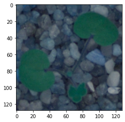

```python
# Test the printing of one images alond with its classifcation
image1 = images[7]
plt.imshow(image1)
print('Image is: ', fig7)
```

```python
# Check the image matrix data type (could know the bit depth of the image)
print(image1.dtype)
# Check the height of image
print(image1.shape[0])
# Check the width of image
print(image1.shape[1])
# Check the number of channels of the image
print(image1.shape[2])
```

```
uint8
128
128
3
```

```
Clipping input data to the valid range for imshow with RGB data ([0..1] for floats or [0..255] for integers).
```

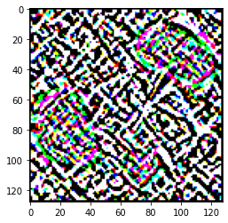

```python
# Test the use of the Sobel filter
sobel = cv2.Sobel(image1, cv2.CV_64F, 1, 1, ksize=5)
plt.imshow(sobel)
```

```python
# Display the numeric value from using the previous figure 7
images[7]   # X pixel values 0 to 255
```

```
array([[[ 74,  99, 113],
        [ 78, 106, 120],
        [ 82, 108, 125],
        ...,
        [ 83,  97, 107],
        [ 91, 104, 112],
        [ 94, 109, 117]],

       [[ 71,  96, 109],
        [ 77, 105, 117],
        [ 72,  97, 115],
        ...,
        [ 97, 114, 118],
        [ 93, 108, 115],
        [ 99, 114, 123]],

       [[ 74,  98, 108],
        [ 82, 106, 117],
        [ 81, 101, 119],
        ...,
        [104, 120, 124],
        [103, 118, 124],
        [ 99, 114, 124]],

       ...,

       [[ 44,  42,  67],
        [ 38,  39,  64],
        [ 58,  63,  79],
        ...,
        [ 30,  40,  65],
        [ 35,  46,  71],
        [ 32,  47,  74]],

       [[ 39,  41,  65],
        [ 27,  30,  58],
        [ 43,  48,  69],
        ...,
        [ 27,  33,  58],
        [ 17,  28,  56],
        [ 26,  45,  73]],

       [[ 32,  36,  63],
        [ 28,  32,  59],
        [ 33,  39,  61],
        ...,
        [ 38,  55,  73],
        [ 37,  61,  81],
        [ 50,  78,  98]]], dtype=uint8)
```

```python
# 2a Data Pre-processing - Normalize the data between 0 and 1
X = images.astype('float32') / 255.0
```

```python
# Display the normalized image and verify values are between 0 and 1
X[7]   #  X noramized
```

```
array([[[0.2901961 , 0.3882353 , 0.44313726],
        [0.30588236, 0.41568628, 0.47058824],
        [0.32156864, 0.42352942, 0.49019608],
        ...,
        [0.3254902 , 0.38039216, 0.41960785],
        [0.35686275, 0.40784314, 0.4392157 ],
        [0.36862746, 0.42745098, 0.45882353]],

       [[0.2784314 , 0.3764706 , 0.42745098],
        [0.3019608 , 0.4117647 , 0.45882353],
        [0.28235295, 0.38039216, 0.4509804 ],
        ...,
        [0.38039216, 0.44705883, 0.4627451 ],
        [0.3647059 , 0.42352942, 0.4509804 ],
        [0.3882353 , 0.44705883, 0.48235294]],

       [[0.2901961 , 0.38431373, 0.42352942],
        [0.32156864, 0.41568628, 0.45882353],
        [0.31764707, 0.39607844, 0.46666667],
        ...,
        [0.40784314, 0.47058824, 0.4862745 ],
        [0.40392157, 0.4627451 , 0.4862745 ],
        [0.3882353 , 0.44705883, 0.4862745 ]],

       ...,

       [[0.17254902, 0.16470589, 0.2627451 ],
        [0.14901961, 0.15294118, 0.2509804 ],
        [0.22745098, 0.24705882, 0.30980393],
        ...,
        [0.11764706, 0.15686275, 0.25490198],
        [0.13725491, 0.18039216, 0.2784314 ],
        [0.1254902 , 0.18431373, 0.2901961 ]],

       [[0.15294118, 0.16078432, 0.25490198],
        [0.10588235, 0.11764706, 0.22745098],
        [0.16862746, 0.1882353 , 0.27058825],
        ...,
        [0.10588235, 0.12941177, 0.22745098],
        [0.06666667, 0.10980392, 0.21960784],
        [0.10196079, 0.1764706 , 0.28627452]],

       [[0.1254902 , 0.14117648, 0.24705882],
        [0.10980392, 0.1254902 , 0.23137255],
        [0.12941177, 0.15294118, 0.23921569],
        ...,
        [0.14901961, 0.21568628, 0.28627452],
        [0.14509805, 0.23921569, 0.31764707],
        [0.19607843, 0.30588236, 0.38431373]]], dtype=float32)
```

```python
# 2b Data Pre-processing - Gaussian Blurring - blur the image to remove noise.
blurr_X = X
for i in range(len(X)):
    # add gaussian blurring
    blurr = cv2.GaussianBlur(X[i], (7, 7), 0)
    blurr_X[i] = blurr
```

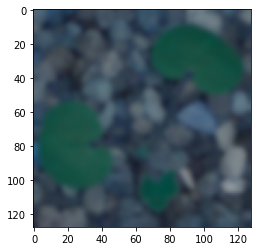

```python
# Display one of the blurred images
image2 = blurr_X[7]
plt.imshow(image2)
```

```
Clipping input data to the valid range for imshow with RGB data ([0..1] for floats or [0..255] for integers).
```

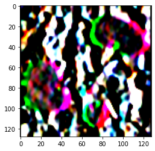

```python
# Test the use of the Sobel filter on the blurred image
sobel = cv2.Sobel(image2,cv2.CV_64F,1,0,ksize=5)
plt.imshow(sobel)
```

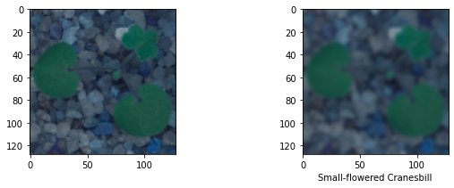

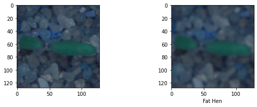

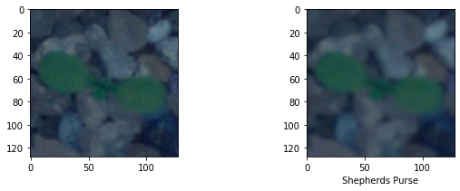

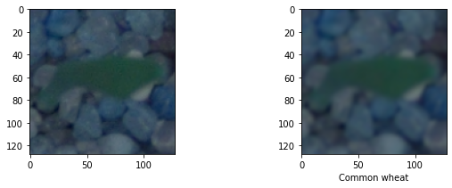

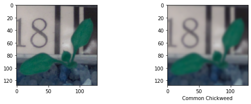

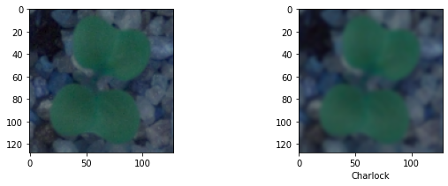

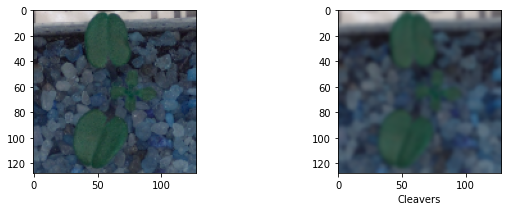

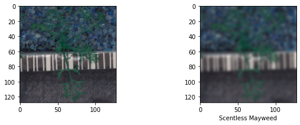

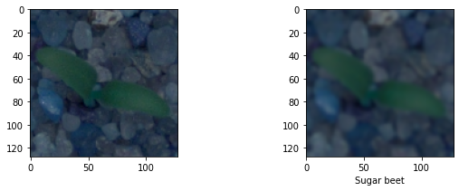

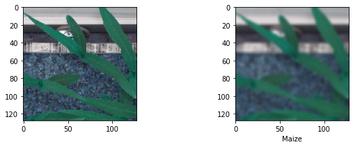

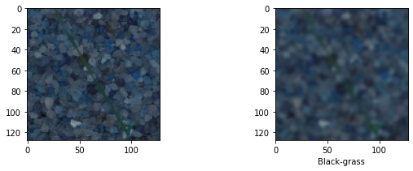

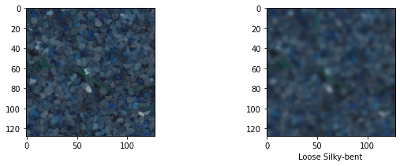

```python
# 2c Data Pre-processing - Visualize data after pre-processing.
# Print samples of the 12 Plant Seedlings
for i in range(4740):
    first = Labels_data.Label[i]
    next = Labels_data.Label[i+1]
    if (first != next):
       j = i + 1
       f = plt.figure(figsize=(10,3))
       ax1 = f.add_subplot(121)
       ax2 = f.add_subplot(122)
       im1 = ax1.imshow(images[i])  # Original10
       im2 = ax2.imshow(blurr_X[i]) # Blurred
       plt.xlabel(Labels_data.Label[i])
       plt.show()

f = plt.figure(figsize=(10,3))
ax1 = f.add_subplot(121)
ax2 = f.add_subplot(122)
im1 = ax1.imshow(images[j])  # Original10
im2 = ax2.imshow(blurr_X[j]) # Blurred
plt.xlabel(Labels_data.Label[j])
plt.show()
```

```python
# 3a Make data compatible - Convert labels to one-hot-vectors.
ohe = OneHotEncoder()
Y = ohe.fit_transform(Labels_data).toarray()
label_names = np.array(ohe.categories_)
for i in range(num_classes):
    print(i, label_names[0,i])
```

```
0 Black-grass
1 Charlock
2 Cleavers
3 Common Chickweed
4 Common wheat
5 Fat Hen
6 Loose Silky-bent
7 Maize
8 Scentless Mayweed
9 Shepherds Purse
10 Small-flowered Cranesbill
11 Sugar beet
```

```
10 Small-flowered Cranesbill
[0. 0. 0. 0. 0. 0. 0. 0. 0. 0. 1. 0.]
```

```
<function matplotlib.pyplot.show>
```

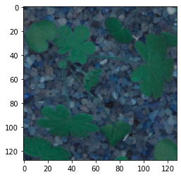

```python
# Test the argmax function to verify the ability to select the highest valued output from the 12 possible outcomes
print(np.argmax(Y[133]), Labels_data.Label[np.argmax(Y[133])])
print(Y[133])
plt.imshow(images[133])
plt.show
```

```python
# 3b Make data compatible - Print the label for y_train[0]
print(Y[0], '  ', Labels_data.Label[0], label_names[0,10])
```

```
[0. 0. 0. 0. 0. 0. 0. 0. 0. 0. 1. 0.]    Small-flowered Cranesbill Small-flowered Cranesbill
```

```python
# 3c Make data compatible - Split the dataset into training, testing, and validation set.(Hint: First split images and labels
# into training and testing set with test_size = 0.3. Then further split test data into test and validation
# set with test_size = 0.5)
X_train, X_test, y_train, y_test = train_test_split(blurr_X, Y, test_size=0.3, random_state=7)
print('Split 1')
print(X_train.shape)
print(X_test.shape)
print(y_train.shape)
print(y_test.shape)
print('Split 2')
X_test, X_validate, y_test, y_validate = train_test_split(X_test, y_test, test_size=0.5, random_state=7)
print(X_test.shape)
print(X_validate.shape)
print(y_test.shape)
print(y_validate.shape)
```

```
Split 1
(3325, 128, 128, 3)
(1425, 128, 128, 3)
(3325, 12)
(1425, 12)
Split 2
(712, 128, 128, 3)
(713, 128, 128, 3)
(712, 12)
(713, 12)
```

```python
# 3d Make data compatible - Check the shape of data, Reshape data into shapes compatible with Keras models if it’s not already.
# If it’s already in the compatible shape, then comment in the notebook that it’s already in compatible shape.
X_train = X_train.reshape(X_train.shape[0], 128, 128, 3)
X_validate = X_validate.reshape(X_validate.shape[0], 128, 128, 3)
X_test = X_test.reshape(X_test.shape[0], 128, 128, 3)
```

```python
# 4a Building CNN - Define layers.
model = keras.Sequential()
# Block 1
model.add(keras.layers.Conv2D(32, (5, 5), padding='same', activation="relu", input_shape=blurr_X.shape[1:], name='Conv_1'))
model.add(keras.layers.BatchNormalization())
model.add(keras.layers.MaxPooling2D((2, 2)))
model.add(keras.layers.Dropout(0.1))
# Block 2
model.add(keras.layers.Conv2D(64, (5, 5), padding='same', activation="relu", name='Conv_2'))
model.add(keras.layers.BatchNormalization())
model.add(keras.layers.MaxPooling2D((2, 2)))
model.add(keras.layers.Dropout(0.1))
# Block 3
model.add(keras.layers.Conv2D(128, (3, 3), padding='same', activation="relu", name='Conv_3'))
model.add(keras.layers.BatchNormalization())
model.add(keras.layers.MaxPooling2D((2, 2)))
model.add(keras.layers.Dropout(0.1))
# Block 4
model.add(keras.layers.Conv2D(64, (3, 3), padding='same', activation="relu", name='Conv_4'))
model.add(keras.layers.BatchNormalization())
model.add(keras.layers.MaxPooling2D((2, 2)))
model.add(keras.layers.Dropout(0.3))
# Block 5
model.add(keras.layers.GlobalMaxPooling2D())
model.add(keras.layers.Dense(512, activation="relu", name='dense_1'))
model.add(keras.layers.Dense(256, activation="relu", name='dense_2'))
model.add(keras.layers.Dense(12, activation="softmax", name='output'))
model.summary()
```

```
Model: "sequential"
_________________________________________________________________
Layer (type)                 Output Shape              Param #
=================================================================
Conv_1 (Conv2D)              (None, 128, 128, 32)      2432
_________________________________________________________________
batch_normalization (BatchNo (None, 128, 128, 32)      128
_________________________________________________________________
max_pooling2d (MaxPooling2D) (None, 64, 64, 32)        0
_________________________________________________________________
dropout (Dropout)            (None, 64, 64, 32)        0
_________________________________________________________________
Conv_2 (Conv2D)              (None, 64, 64, 64)        51264
_________________________________________________________________
batch_normalization_1 (Batch (None, 64, 64, 64)        256
_________________________________________________________________
max_pooling2d_1 (MaxPooling2 (None, 32, 32, 64)        0
_________________________________________________________________
dropout_1 (Dropout)          (None, 32, 32, 64)        0
_________________________________________________________________
Conv_3 (Conv2D)              (None, 32, 32, 128)       73856
_________________________________________________________________
batch_normalization_2 (Batch (None, 32, 32, 128)       512
_________________________________________________________________
max_pooling2d_2 (MaxPooling2 (None, 16, 16, 128)       0
_________________________________________________________________
dropout_2 (Dropout)          (None, 16, 16, 128)       0
_________________________________________________________________
Conv_4 (Conv2D)              (None, 16, 16, 64)        73792
_________________________________________________________________
batch_normalization_3 (Batch (None, 16, 16, 64)        256
_________________________________________________________________
max_pooling2d_3 (MaxPooling2 (None, 8, 8, 64)          0
_________________________________________________________________
dropout_3 (Dropout)          (None, 8, 8, 64)          0
_________________________________________________________________
global_max_pooling2d (Global (None, 64)                0
_________________________________________________________________
dense_1 (Dense)              (None, 512)               33280
_________________________________________________________________
dense_2 (Dense)              (None, 256)               131328
_________________________________________________________________
output (Dense)               (None, 12)                3084
=================================================================
Total params: 370,188
Trainable params: 369,612
Non-trainable params: 576
_________________________________________________________________
```

```python
# 4b Building CNN - Set optimizer and loss function. (Use Adam optimizer and categorical crossentropy.)
opt = keras.optimizers.Adam(learning_rate=0.0001, beta_1=0.9, beta_2=0.999, epsilon=1e-08)
model.compile(loss='categorical_crossentropy', optimizer=opt, metrics=['accuracy'])
```

```python
# 5 Fit and evaluate modeland print confusion matrix.
es = EarlyStopping(monitor='val_loss', mode='min', verbose=1, patience=10)
mc =  ModelCheckpoint(filepath='/content/drive/My Drive/cifar_cnn_checkpoint_{epoch:02d}_loss{val_loss:.2f}.hdf5',
                                                           monitor='val_loss',
                                                           verbose=1,
                                                           save_best_only=True,
                                                           save_weights_only=True,
                                                           mode='min',
                                                           save_freq='epoch')
```

```python
history = model.fit(X_train,
                    y_train,
                    batch_size=batch_size,
                    epochs=epochs,
                    validation_data=(X_validate, y_validate),
                    shuffle=True,
                    verbose=1,
                    callbacks=[es, mc])
```

```
Epoch 00001: val_loss improved from inf to 2.46837, saving model to /content/drive/My Drive/cifar_cnn_checkpoint_01_loss2.47.hdf5
Epoch 00002: val_loss improved from 2.46837 to 2.46709, saving model to /content/drive/My Drive/cifar_cnn_checkpoint_02_loss2.47.hdf5
Epoch 00003: val_loss improved from 2.46709 to 2.38631, saving model to /content/drive/My Drive/cifar_cnn_checkpoint_03_loss2.39.hdf5
Epoch 00004: val_loss improved from 2.38631 to 2.14799, saving model to /content/drive/My Drive/cifar_cnn_checkpoint_04_loss2.15.hdf5
Epoch 00005: val_loss improved from 2.14799 to 1.80025, saving model to /content/drive/My Drive/cifar_cnn_checkpoint_05_loss1.80.hdf5
Epoch 00006: val_loss improved from 1.80025 to 1.44528, saving model to /content/drive/My Drive/cifar_cnn_checkpoint_06_loss1.45.hdf5
Epoch 00007: val_loss improved from 1.44528 to 1.21556, saving model to /content/drive/My Drive/cifar_cnn_checkpoint_07_loss1.22.hdf5
Epoch 00008: val_loss did not improve from 1.21556
Epoch 00009: val_loss improved from 1.21556 to 0.87975, saving model to /content/drive/My Drive/cifar_cnn_checkpoint_09_loss0.88.hdf5
Epoch 00010: val_loss improved from 0.87975 to 0.86822, saving model to /content/drive/My Drive/cifar_cnn_checkpoint_10_loss0.87.hdf5
Epoch 00011: val_loss improved from 0.86822 to 0.77353, saving model to /content/drive/My Drive/cifar_cnn_checkpoint_11_loss0.77.hdf5
Epoch 00012: val_loss improved from 0.77353 to 0.67745, saving model to /content/drive/My Drive/cifar_cnn_checkpoint_12_loss0.68.hdf5
Epoch 00013: val_loss did not improve from 0.67745
Epoch 00014: val_loss improved from 0.67745 to 0.67499, saving model to /content/drive/My Drive/cifar_cnn_checkpoint_14_loss0.67.hdf5
Epoch 00015: val_loss improved from 0.67499 to 0.61129, saving model to /content/drive/My Drive/cifar_cnn_checkpoint_15_loss0.61.hdf5
Epoch 00016: val_loss did not improve from 0.61129
Epoch 00017: val_loss did not improve from 0.61129
Epoch 00018: val_loss did not improve from 0.61129
Epoch 00019: val_loss improved from 0.61129 to 0.59675, saving model to /content/drive/My Drive/cifar_cnn_checkpoint_19_loss0.60.hdf5
Epoch 00020: val_loss improved from 0.59675 to 0.56253, saving model to /content/drive/My Drive/cifar_cnn_checkpoint_20_loss0.56.hdf5
Epoch 00021: val_loss improved from 0.56253 to 0.48350, saving model to /content/drive/My Drive/cifar_cnn_checkpoint_21_loss0.48.hdf5
Epoch 00022: val_loss did not improve from 0.48350
Epoch 00023: val_loss improved from 0.48350 to 0.44470, saving model to /content/drive/My Drive/cifar_cnn_checkpoint_23_loss0.44.hdf5
Epoch 00024: val_loss did not improve from 0.44470
Epoch 00025: val_loss did not improve from 0.44470
Epoch 00026: val_loss did not improve from 0.44470
Epoch 00027: val_loss did not improve from 0.44470
Epoch 00028: val_loss did not improve from 0.44470
Epoch 00029: val_loss did not improve from 0.44470
Epoch 00030: val_loss improved from 0.44470 to 0.43392, saving model to /content/drive/My Drive/cifar_cnn_checkpoint_30_loss0.43.hdf5
Epoch 00031: val_loss did not improve from 0.43392
Epoch 00032: val_loss did not improve from 0.43392
Epoch 00033: val_loss did not improve from 0.43392
Epoch 00034: val_loss did not improve from 0.43392
Epoch 00035: val_loss improved from 0.43392 to 0.43364, saving model to /content/drive/My Drive/cifar_cnn_checkpoint_35_loss0.43.hdf5
Epoch 00036: val_loss improved from 0.43364 to 0.41378, saving model to /content/drive/My Drive/cifar_cnn_checkpoint_36_loss0.41.hdf5
Epoch 00037: val_loss did not improve from 0.41378
Epoch 00038: val_loss did not improve from 0.41378
Epoch 00039: val_loss improved from 0.41378 to 0.36733, saving model to /content/drive/My Drive/cifar_cnn_checkpoint_39_loss0.37.hdf5
Epoch 00040: val_loss did not improve from 0.36733
Epoch 00041: val_loss did not improve from 0.36733
Epoch 00042: val_loss did not improve from 0.36733
Epoch 00043: val_loss did not improve from 0.36733
Epoch 00044: val_loss improved from 0.36733 to 0.31838, saving model to /content/drive/My Drive/cifar_cnn_checkpoint_44_loss0.32.hdf5
Epoch 00045: val_loss did not improve from 0.31838
Epoch 00046: val_loss did not improve from 0.31838
Epoch 00047: val_loss did not improve from 0.31838
Epoch 00048: val_loss did not improve from 0.31838
Epoch 00049: val_loss did not improve from 0.31838
Epoch 00050: val_loss did not improve from 0.31838
Epoch 00051: val_loss did not improve from 0.31838
Epoch 00052: val_loss did not improve from 0.31838
Epoch 00053: val_loss did not improve from 0.31838
Epoch 00054: val_loss did not improve from 0.31838
Epoch 00054: early stopping
```

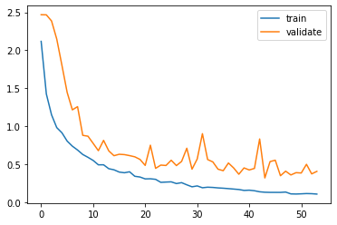

```python
# plot training history
plt.plot(history.history['loss'], label='train')
plt.plot(history.history['val_loss'], label='validate')
plt.legend()
plt.show()
```

```python
# Score trained model.
scores = model.evaluate(X_test, y_test, verbose=1)
print('Test loss:', scores[0])
print('Test accuracy:', scores[1])
```

```
Test loss: 0.3129965364933014
Test accuracy: 0.8932584524154663
```

```
11
[0. 0. 0. 0. 0. 0. 0. 0. 0. 0. 0. 1.]
x_test[2] is:  Sugar beet
```

```
<function matplotlib.pyplot.show>
```

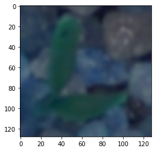

```python
# 6 Visualize predictions for x_test[2], x_test[3], x_test[33], x_test[36], x_test[59].
probability_model = keras.Sequential([model,keras.layers.Softmax()])
test_image = X_test[2]
pred = probability_model.predict(test_image.reshape(1, 128, 128,3))
image_id = np.argmax(pred[0])
print(image_id)
print(y_test[2])
print('x_test[2] is: ', label_names[0,image_id])
plt.imshow(test_image)
plt.show
```

Comment: #1 Correct Classification

```
2
[0. 0. 1. 0. 0. 0. 0. 0. 0. 0. 0. 0.]
x_test[3] is:  Cleavers
```

```
<function matplotlib.pyplot.show>
```

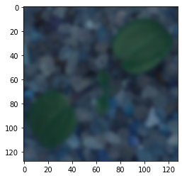

```python
test_image = X_test[3]
pred = probability_model.predict(test_image.reshape(1, 128, 128,3))
image_id = np.argmax(pred[0])
print(image_id)
print(y_test[3])
print('x_test[3] is: ',label_names[0,image_id])
plt.imshow(test_image)
plt.show
```

Comment: #2 Correct Classification

```
2
[0. 0. 1. 0. 0. 0. 0. 0. 0. 0. 0. 0.]
x_test[33] is:  Cleavers
```

```
<function matplotlib.pyplot.show>
```

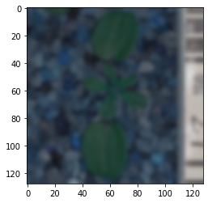

```python
test_image = X_test[33]
pred = probability_model.predict(test_image.reshape(1, 128, 128,3))
image_id = np.argmax(pred[0])
print(image_id)
print(y_test[33])
print('x_test[33] is: ',label_names[0,image_id])
plt.imshow(test_image)
plt.show
```

Comment: #3 Correct Classification

```
0
[1. 0. 0. 0. 0. 0. 0. 0. 0. 0. 0. 0.]
x_test[36] is:  Black-grass
```

```
<function matplotlib.pyplot.show>
```

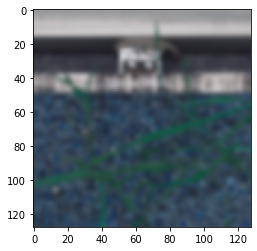

```python
test_image = X_test[36]
pred = probability_model.predict(test_image.reshape(1, 128, 128,3))
image_id = np.argmax(pred)
print(image_id)
print(y_test[36])
print('x_test[36] is: ',label_names[0,image_id])
plt.imshow(test_image)
plt.show
```

Comment: #4 Correct Classification

```
7
[0. 0. 0. 0. 0. 0. 0. 1. 0. 0. 0. 0.]
x_test[59] is:  Maize
```

```
<function matplotlib.pyplot.show>
```

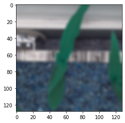

```python
test_image = X_test[59]
pred = probability_model.predict(test_image.reshape(1, 128, 128,3))
image_id = np.argmax(pred)
print(image_id)
print(y_test[59])
print('x_test[59] is: ',label_names[0,image_id])
plt.imshow(test_image)
plt.show
```

Comment: #5 Correct Classification

Conclusion: The model was run many times with different architectures, epochs, number of filters, and filer sizes. The goal was to get the evaluation accuracy above 80%.

Based on the above results for accuracy: Train 96%,  
Validate 87%, and Test 89%.

The project also required to predict the classification for 5 images in the test dataset. The model was able to correctly classy the 5 images. Since the model has an accuracy around 90%, one should expect incorrect classifications with other images.